# MAE calculation with Bootstrapping example

Dave Hurst

20 October, 2015

Starts with the Kaggle Script mpalmer.R Original comments are below:

This file calculates the MAE of the entire training set, using the Marshall-Palmer as the predicted values. MAE for the training set is 23.4304 versus 24.0697 for the test set.

Next I recalulate for 20 random samples of 10% of the dataset. I plot the resulting histogram. This technique is essentially bootstrapping, and the median value should be a close approximation of the original (training population). It should give us an idea of the spread we would expect to see from random samples of the same size.

```r
# > This is an R implementation of sample_dask.py. It uses the Marshall-Palmer relation
# > to calculate hourly rain rates for each Id. It produces a submission file identical
# > to the 'sample_solution.csv' file provided in the Data section of this competition
# > to at least 9 decimal places. It earns a MAE score of 24.06968 on the leaderboard
# > exactly equal to the sample solution benchmark. And it's faster ;)
```

```
## loading train from RData file
```

```
##    user  system elapsed
##   12.42    1.39   25.51
```

Here’s the code and results to check the MAE of the entire population

```r
rainfall <- train[ ,.(
    yhat = mpalmer(Ref, minutes_past)
    , y = max(Expected)
), Id][ yhat >= 0, ]

mae_trn <- with(rainfall, mae( yhat, y)  )  #23.4304
mae_trn
```

```
## [1] 23.4304
```

```r
tcheck()
```

```
##    user  system elapsed
##  103.13    0.12  104.16
```

MAE for the entire population of the training set is 23.4303955 which compares reasonable to the MAE of 24.06968 for the mpalmer script on the public leader board (LB).

The full training set contains 1180945 records, and is unweildy to work with so we want to see what the range MAE values for smaller sets.

```r
set.seed(2015)
n_id <- length( unique(train$Id) )
n_fold <- 20
fraction <- 0.1
scores <- numeric()
```

Here I’m sampling a fraction = 10% of the data 20 times and recording the MAE for the sample in `scores`

[output not shown]

```
##    Min. 1st Qu.  Median    Mean 3rd Qu.    Max.
##   20.94   23.04   23.30   23.28   23.63   24.58
```

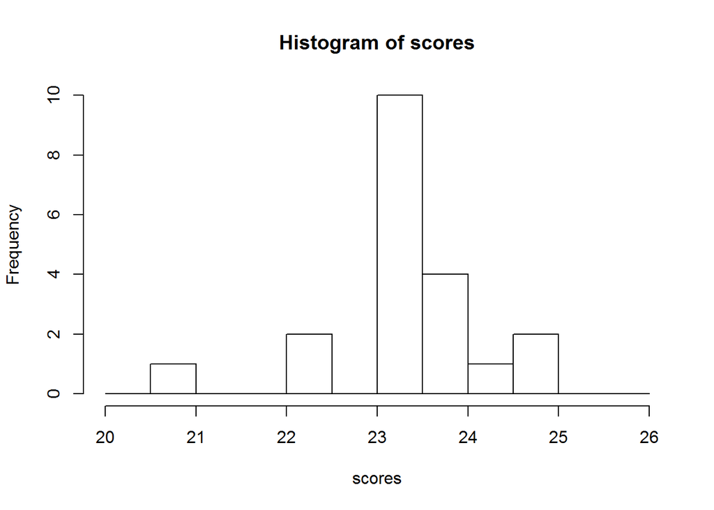

```
##    user  system elapsed
##  225.03    2.04  228.41
```

This is essentially bootstrapping, so the following values should be decent approximations of our training (and hopefully test) population.

- Mean of Bootstrapped samples = 23.2830093
- Median of Bootstrapped samples = 23.3026861
- StDev of Bootstrapped samples = 0.8202143